# Drilling Data Bit Failure Prediction

Ala Qabaja

July 5th, 2017

## Data Reading and Transformation

Data was read from csv files and loaded into SQL server. Data was consumed directly from SQL server.

A quick look at the data and dimensionality In reading, all data rows with negative hole depth were excluded

```r
df_original_31862 = DrillingFileReader(wellName = "well_31862")
dim(df_original_31862)
```

```
## [1] 150214    166
```

```r
df_original_31943 = DrillingFileReader(wellName = "well_31943")
dim(df_original_31943)
```

```
## [1] 98295   166
```

```r
df_original_31944 = DrillingFileReader(wellName = "well_31944")
dim(df_original_31944)
```

```
## [1] 68994   166
```

```r
df_original_31945 = DrillingFileReader(wellName = "well_31945")
dim(df_original_31944)
```

```
## [1] 68994   166
```

```r
df_original_31946 = DrillingFileReader(wellName = "well_31946")
dim(df_original_31946)
```

```
## [1] 79027   166
```

```r
df_original_31947 = DrillingFileReader(wellName = "well_31947")
dim(df_original_31947)
```

```
## [1] 60279   166
```

```r
df_original_31948 = DrillingFileReader(wellName = "well_31948")
dim(df_original_31948)
```

```
## [1] 59056   166
```

```r
df_original_32202 = DrillingFileReader(wellName = "well_32202")
dim(df_original_32202)
```

```
## [1] 91860   166
```

After reading the data, we needed to get rid of constant columns. Example of a constant column

```r
options(warn = -1)
constCols_31862 = DetectConstantCols(dataSource = df_original_31862)
constCols_31862
```

```
##  [1] "AccumTripIn"                    "AirPressure"
##  [3] "AverageJointLength"             "DailyAccumWear"
##  [5] "PitVolume10"                    "DrillingTriggerHKLD"
##  [7] "GWPumpShutdown"                 "GWStatus"
##  [9] "GWVacuum"                       "GWVacuumMax"
## [11] "GWAMethaneC1"                   "GWANorPentaneNC5"
## [13] "GWAPropaneC3"                   "MudWeightIn"
## [15] "MudWeightOut"                   "PipeID"
## [17] "PipeOD"                         "PitVolume7"
## [19] "PrevDayWear"                    "PumpSPM3"
## [21] "RigActivity"                    "SoftSpeedEffectiveMotorInertia"
## [23] "SoftSpeedIGain"                 "StrksAccDrill"
## [25] "StrksAccFill"                   "StrksPump1"
## [27] "StrksPump2"                     "StrksPump3"
## [29] "ToolfaceThreshold"              "TorqueDiff"
## [31] "TotalGas"                       "TotalGasNormalized"
## [33] "TotalGasOut"                    "PitVolume11"
## [35] "APSAUXINC"                      "TripTank2"
## [37] "TrippingTriggerHKLD"            "NBINC"
## [39] "WaterPit"                       "WCReamSpeed"
```

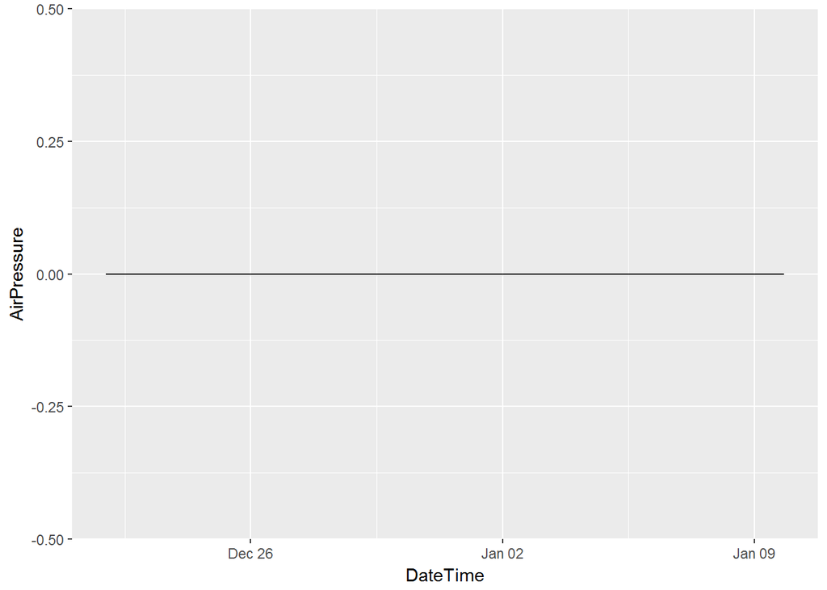

```r
ggplot(data = df_original_31862, aes(x = DateTime , y = AirPressure)) + geom_line()
```

```r
constCols_31943 = DetectConstantCols(dataSource = df_original_31943)
constCols_31944 = DetectConstantCols(dataSource = df_original_31944)
constCols_31945 = DetectConstantCols(dataSource = df_original_31945)
constCols_31946 = DetectConstantCols(dataSource = df_original_31946)
constCols_31947 = DetectConstantCols(dataSource = df_original_31947)
constCols_31948 = DetectConstantCols(dataSource = df_original_31948)
constCols_32202 = DetectConstantCols(dataSource = df_original_32202)
options(war = 0)
```

The list of all constant columns from all wells is

```r
## Constant Columns from different wells
uniqueConstCols = unique(c(constCols_31862, constCols_31943, constCols_31944, constCols_31945, constCols_31946, constCols_31947, constCols_31948, constCols_32202))
uniqueConstCols
```

```
##  [1] "AccumTripIn"                    "AirPressure"
##  [3] "AverageJointLength"             "DailyAccumWear"
##  [5] "PitVolume10"                    "DrillingTriggerHKLD"
##  [7] "GWPumpShutdown"                 "GWStatus"
##  [9] "GWVacuum"                       "GWVacuumMax"
## [11] "GWAMethaneC1"                   "GWANorPentaneNC5"
## [13] "GWAPropaneC3"                   "MudWeightIn"
## [15] "MudWeightOut"                   "PipeID"
## [17] "PipeOD"                         "PitVolume7"
## [19] "PrevDayWear"                    "PumpSPM3"
## [21] "RigActivity"                    "SoftSpeedEffectiveMotorInertia"
## [23] "SoftSpeedIGain"                 "StrksAccDrill"
## [25] "StrksAccFill"                   "StrksPump1"
## [27] "StrksPump2"                     "StrksPump3"
## [29] "ToolfaceThreshold"              "TorqueDiff"
## [31] "TotalGas"                       "TotalGasNormalized"
## [33] "TotalGasOut"                    "PitVolume11"
## [35] "APSAUXINC"                      "TripTank2"
## [37] "TrippingTriggerHKLD"            "NBINC"
## [39] "WaterPit"                       "WCReamSpeed"
## [41] "ADTargetTorque"                 "ChokePosition2"
```

Then we needed to get rid of columns with missing values. Example

```r
missCols_31862 = DetectColsWithMissingValues(df_0_31862, missValuesPercent= 5)
missCols_31862
```

```
##  [1] "GammaDepth1"    "GammaRay"       "QLReturnsDepth" "ROPAverage"
##  [5] "ROPCutUnit"     "ROPFast1"       "ROPFast"        "SvyAzimuth"
##  [9] "SvyInclination" "ToolfaceGrav"   "ToolfaceMag"    "TVDwits"
```

```r
missCols_31943 = DetectColsWithMissingValues(df_0_31943, missValuesPercent= 5)
missCols_31943
```

```
## [1] "GammaDepth1"    "GammaRay"       "QLReturnsDepth" "SvyAzimuth"
## [5] "SvyInclination" "ToolfaceGrav"   "ToolfaceMag"    "TotalGasGW"
## [9] "TVDwits"
```

```r
missCols_31944 = DetectColsWithMissingValues(df_0_31944, missValuesPercent= 5)
missCols_31944
```

```
##  [1] "GammaDepth1"          "GammaRay"             "QLDepthDelay"
##  [4] "QLReturnsDepth"       "ReturnsDepthRealtime" "SvyAzimuth"
##  [7] "SvyInclination"       "ToolfaceGrav"         "ToolfaceMag"
## [10] "TVDwits"
```

```r
missCols_31945 = DetectColsWithMissingValues(df_0_31945, missValuesPercent= 5)
missCols_31945
```

```
##  [1] "GammaDepth1"          "GammaRay"             "QLDepthDelay"
##  [4] "QLReturnsDepth"       "ReturnsDepthRealtime" "SvyAzimuth"
##  [7] "SvyInclination"       "ToolfaceGrav"         "ToolfaceMag"
## [10] "TVD1"                 "TVDwits"
```

```r
missCols_31946 = DetectColsWithMissingValues(df_0_31946, missValuesPercent= 5)
missCols_31946
```

```
##  [1] "GammaDepth1"          "GammaRay"             "QLDepthDelay"
##  [4] "QLReturnsDepth"       "ReturnsDepthRealtime" "RigActivityCode"
##  [7] "RigActivityEngine"    "RigActivitySubCode"   "SvyAzimuth"
## [10] "SvyInclination"       "ToolfaceGrav"         "ToolfaceMag"
## [13] "TVD1"                 "TVDwits"
```

```r
missCols_31947 = DetectColsWithMissingValues(df_0_31947, missValuesPercent= 5)
missCols_31947
```

```
##  [1] "GammaDepth1"    "GammaRay"       "QLReturnsDepth" "SvyAzimuth"
##  [5] "SvyInclination" "ToolfaceGrav"   "ToolfaceMag"    "TotalGasGW"
##  [9] "TVD1"           "TVDwits"
```

```r
missCols_31948 = DetectColsWithMissingValues(df_0_31948, missValuesPercent= 5)
missCols_31948
```

```
##  [1] "GammaDepth1"          "GammaRay"             "QLDepthDelay"
##  [4] "QLReturnsDepth"       "ReturnsDepthRealtime" "SvyAzimuth"
##  [7] "SvyInclination"       "ToolfaceGrav"         "ToolfaceMag"
## [10] "TVD1"                 "TVDwits"
```

```r
## so many missing values. We should exclude this experiment for now
missCols_32202 = DetectColsWithMissingValues(df_0_32202, missValuesPercent= 5)
missCols_32202
```

```
##  [1] "ADLoopInControl"                "ADROP"
##  [3] "ADTargetBitWeight"              "ADTargetROP"
##  [5] "AnnularVelocity"                "BitHours"
##  [7] "BitTVD"                         "CirculatingHrs"
##  [9] "CoManGL"                        "GainLoss"
## [11] "GainLossSpare"                  "GammaDepth1"
## [13] "GammaRay"                       "LstElemLen"
## [15] "LstJntTime"                     "MudVolume"
## [17] "PipeLengthChange"               "PitVolume1"
## [19] "PillTank"                       "PitVolume2"
## [21] "PitVolume3"                     "PitVolume4"
## [23] "PitVolume5"                     "Flock1"
## [25] "Flock2"                         "Flock3"
## [27] "PTCorrection"                   "QLDepthDelay"
## [29] "QLReturnsDepth"                 "QLStartDepth"
## [31] "ROPAverage"                     "ROPCutUnit"
## [33] "RunJntTime"                     "SlipStatus"
## [35] "SlipSwitch"                     "SoftSpeedEstimatedBHASpeed"
## [37] "SoftSpeedStringLength"          "SoftSpeedTopDriveSpeed"
## [39] "SoftSpeedTopDriveSpeedSetpoint" "SvyAzimuth"
## [41] "SvyInclination"                 "ToolfaceGrav"
## [43] "ToolfaceMag"                    "TopDriveRPM"
## [45] "TVD1"                           "TVD"
## [47] "TVDwits"                        "WeightonBit"
## [49] "DogLegSeverity"
```

The list of all columns more than 5% missing values are

```r
uniqueMissCols = unique(c(missCols_31862, missCols_31943, missCols_31944, missCols_31945, missCols_31946, missCols_31947, missCols_31948))
## This list needs to be reviewed by Kurt and Kurt should indicate if we need to investigate any column
uniqueMissCols
```

```
##  [1] "GammaDepth1"          "GammaRay"             "QLReturnsDepth"
##  [4] "ROPAverage"           "ROPCutUnit"           "ROPFast1"
##  [7] "ROPFast"              "SvyAzimuth"           "SvyInclination"
## [10] "ToolfaceGrav"         "ToolfaceMag"          "TVDwits"
## [13] "TotalGasGW"           "QLDepthDelay"         "ReturnsDepthRealtime"
## [16] "TVD1"                 "RigActivityCode"      "RigActivityEngine"
## [19] "RigActivitySubCode"
```

Remove these columns from all experiments

```r
df_1_31862 = RemoveColsList(df_0_31862, uniqueMissCols)
df_1_31943 = RemoveColsList(df_0_31943, uniqueMissCols)
df_1_31944 = RemoveColsList(df_0_31944, uniqueMissCols)
df_1_31945 = RemoveColsList(df_0_31945, uniqueMissCols)
df_1_31946 = RemoveColsList(df_0_31946, uniqueMissCols)
df_1_31947 = RemoveColsList(df_0_31947, uniqueMissCols)
df_1_31948 = RemoveColsList(df_0_31948, uniqueMissCols)
df_1_32202 = RemoveColsList(df_0_32202, uniqueMissCols)


dfRemMissCols = data.frame(FeatureName = uniqueMissCols, Reason = "Missing Columns - More than 5% of rows", WellName = "All Wells", Version = "Main")
```

Normalization of Accume Columns What is an accum column

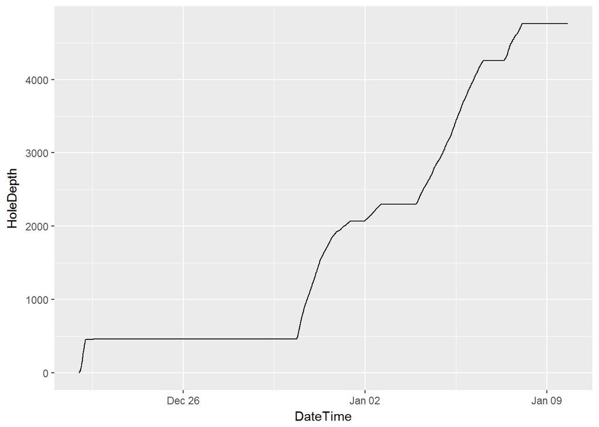

```r
## Plot of Hole Depth measurement accross time
ggplot(data = df_1_31862, aes(x = DateTime, y = HoleDepth)) + geom_line()
```

```r
accumColToNormalize = c("HoleDepth","AccumRotations","BitHours","BitPosition","BitTVD","CirculatingHrs","CutandSlip","GammaDepth","KellyDown","PipeLength","PipeLengthChange",
                        "QLStartDepth","SoftSpeedStringLength","StringLength","StrksFill","TVD","QLStrokesToSurface","QLStksBtUp","HookLoad")

MissConsCols = unique(c(uniqueMissCols, uniqueConstCols))
accumColToNormalize = accumColToNormalize[!(accumColToNormalize %in% MissConsCols)]

df_1_31862 = NormalizeAccumCols(df_1_31862, accumColToNormalize)
df_1_31943 = NormalizeAccumCols(df_1_31943, accumColToNormalize)
df_1_31944 = NormalizeAccumCols(df_1_31944, accumColToNormalize)
df_1_31945 = NormalizeAccumCols(df_1_31945, accumColToNormalize)
df_1_31946 = NormalizeAccumCols(df_1_31946, accumColToNormalize)
df_1_31947 = NormalizeAccumCols(df_1_31947, accumColToNormalize)
df_1_31948 = NormalizeAccumCols(df_1_31948, accumColToNormalize)
df_1_32202 = NormalizeAccumCols(df_1_32202, accumColToNormalize)
```

Remove all columns that were mentioned by Kurt as non-important

```r
unwantedColsKurt =  c("ADTargetWeight", "ADTargetBitWeight", "ADTargetDiffPress","ADTargetROP","ADTargetTorque","PitVolume5","PitVolume4","PitVolume3","PitVolume2","PitVolume1")
unwantedColsKurt
```

```
##  [1] "ADTargetWeight"    "ADTargetBitWeight" "ADTargetDiffPress"
##  [4] "ADTargetROP"       "ADTargetTorque"    "PitVolume5"
##  [7] "PitVolume4"        "PitVolume3"        "PitVolume2"
## [10] "PitVolume1"
```

```r
df_1_31862 = RemoveColsList(df_1_31862, unwantedColsKurt)
df_1_31943 = RemoveColsList(df_1_31943, unwantedColsKurt)
df_1_31944 = RemoveColsList(df_1_31944, unwantedColsKurt)
df_1_31945 = RemoveColsList(df_1_31945, unwantedColsKurt)
df_1_31946 = RemoveColsList(df_1_31946, unwantedColsKurt)
df_1_31947 = RemoveColsList(df_1_31947, unwantedColsKurt)
df_1_31948 = RemoveColsList(df_1_31948, unwantedColsKurt)
df_1_32202 = RemoveColsList(df_1_32202, unwantedColsKurt)
```

Then, data tables needed to be split based on their Hole Depth value. Each Hole depth range represented a failure

```r
df_1_31862_exp1 = df_1_31862[df_1_31862$HoleDepth>= 2296 & df_1_31862$HoleDepth<= 4258, ]
dim(df_1_31862_exp1)
```

```
## [1] 34196    98
```

```r
df_1_31943_exp1 = df_1_31943[df_1_31943$HoleDepth>= 458 & df_1_31943$HoleDepth<= 1626, ]
dim(df_1_31943_exp1)
```

```
## [1] 15255    98
```

```r
df_1_31943_exp2 = df_1_31943[df_1_31943$HoleDepth>= 2095 & df_1_31943$HoleDepth<= 3828, ]
dim(df_1_31943_exp2)
```

```
## [1] 25321    98
```

```r
df_1_31945_exp1 = df_1_31945[df_1_31945$HoleDepth>= 2278 & df_1_31945$HoleDepth<= 3311, ]
dim(df_1_31945_exp1)
```

```
## [1] 17328    98
```

```r
df_1_31946_exp1 = df_1_31946[df_1_31946$HoleDepth>= 2153 & df_1_31946$HoleDepth<= 3767, ]
dim(df_1_31946_exp1)
```

```
## [1] 21980    98
```

```r
df_1_32202_exp1 = df_1_32202[df_1_32202$HoleDepth>= 455 & df_1_32202$HoleDepth<=999, ]
dim(df_1_32202_exp1)
```

```
## [1] 14548    98
```

Plot linear chart for each variable accross all wells

Example on a variable that was kept after Exploitation

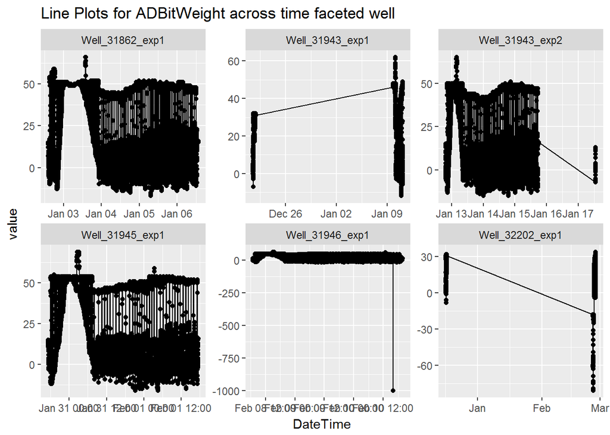

```r
  title <- paste("Line Plots for ADBitWeight across time faceted well")
  p = ggplot(data = dfm_ADBitWeight, aes_string(x = "DateTime", y = "value")) + geom_line()
  p = p + geom_point()
  p = p + facet_wrap(~ Depth , scales="free")
  p = p + ggtitle(title)
  p
```

Example on a variable that was removed after Exploitation

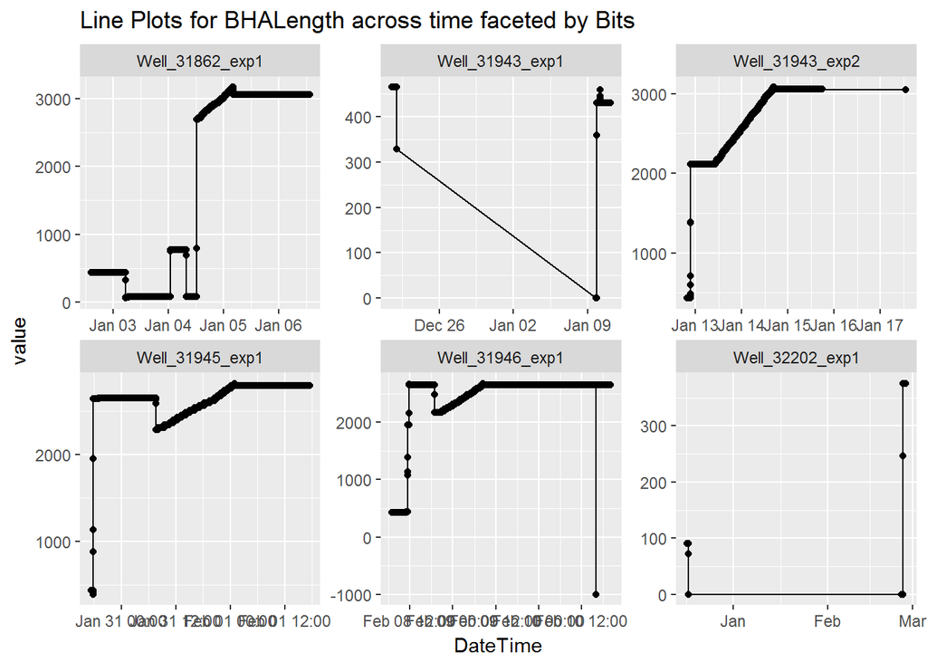

```r
  title <- paste("Line Plots for BHALength across time faceted by Bits")
  p = ggplot(data = dfm_BHALength, aes_string(x = "DateTime", y = "value")) + geom_line()
  p = p + geom_point()
  p = p + facet_wrap(~ Depth , scales="free")
  p = p + ggtitle(title)
  p
```

Filtering out Rows Based on Exploitation

Filtering out Columns based on Exploitation

```r
unwantedColsExploit = c("AccumTripOut" , "BHALength", "BitSize", "BitStatus", "DegasserTankS10DAQ", "HoleDepth", "Last24HrWear", "PumpSPM2","QLTimeToSurface","RigActivityCode", "SoftSpeedActive", "SoftSpeedEffectivePipeOuterDiameter","SoftSpeedPGain",
                        "SoftSpeedStickSlipAnalyzerTime", "SoftSpeedStickSlipRawSeverity", "SoftSpeedTally1BHAID" ,"SoftSpeedTally1BHAlength" ,"SoftSpeedTally1BHAOD" ,"SoftSpeedTally2ID","SoftSpeedTally2length",
                        "SoftSpeedTally2OD" ,"SoftSpeedTally3ID" ,"SoftSpeedTally3length","SoftSpeedTally3OD" ,"SoftSpeedTally4ID" , "SoftSpeedTally4length","SoftSpeedTally4OD"   , "SoftSpeedTDSHeartbeat" , "SoftSpeedTITime","StrksTotal"  , "TotalTripVolume", "TriggerHKLDStatus","TripTank","TripTankGL" , "WPDABitHHP" ,"WPDAStatus",
                        "PumpSPM1", "AccumRotationsDiff","BitHoursDiff","BitPositionDiff","BitTVDDiff","CoManGL","CutandSlipDiff",
                        "DogLegSeverity","Flock1","Flock2","Flock3","GainLoss","GainLossSpare","KellyDownDiff","LstElemLen",
                        "LstJntTime","MudVolume","PillTank","PipeLengthChangeDiff","PipeLengthDiff","PTCorrection","QLStartDepthDiff",
                        "SlipStatus","SlipSwitch","SoftSpeedKpGain","SoftSpeedStringLengthDiff","StringLengthDiff",
                        "StrksFillDiff","TVDDiff")


unwantedColsExploit
```

```
##  [1] "AccumTripOut"
##  [2] "BHALength"
##  [3] "BitSize"
##  [4] "BitStatus"
##  [5] "DegasserTankS10DAQ"
##  [6] "HoleDepth"
##  [7] "Last24HrWear"
##  [8] "PumpSPM2"
##  [9] "QLTimeToSurface"
## [10] "RigActivityCode"
## [11] "SoftSpeedActive"
## [12] "SoftSpeedEffectivePipeOuterDiameter"
## [13] "SoftSpeedPGain"
## [14] "SoftSpeedStickSlipAnalyzerTime"
## [15] "SoftSpeedStickSlipRawSeverity"
```

[output cut: 50 more lines]

```r
df_1_31862_exp1 = RemoveColsList(df_1_31862_exp1,unwantedColsExploit)
df_1_31943_exp1 = RemoveColsList(df_1_31943_exp1,unwantedColsExploit)
df_1_31943_exp2 = RemoveColsList(df_1_31943_exp2,unwantedColsExploit)
df_1_31945_exp1 = RemoveColsList(df_1_31945_exp1,unwantedColsExploit)
df_1_31946_exp1 = RemoveColsList(df_1_31946_exp1,unwantedColsExploit)
df_1_32202_exp1 = RemoveColsList(df_1_32202_exp1,unwantedColsExploit)

dfRemExploitCols = data.frame(FeatureName = unwantedColsExploit, Reason = "Remove Columns based on Exploitation", WellName = "All Wells", Version = "Main")
```

Plot again to make sure everything looks better now

Example on a variable that was kept after Exploitation

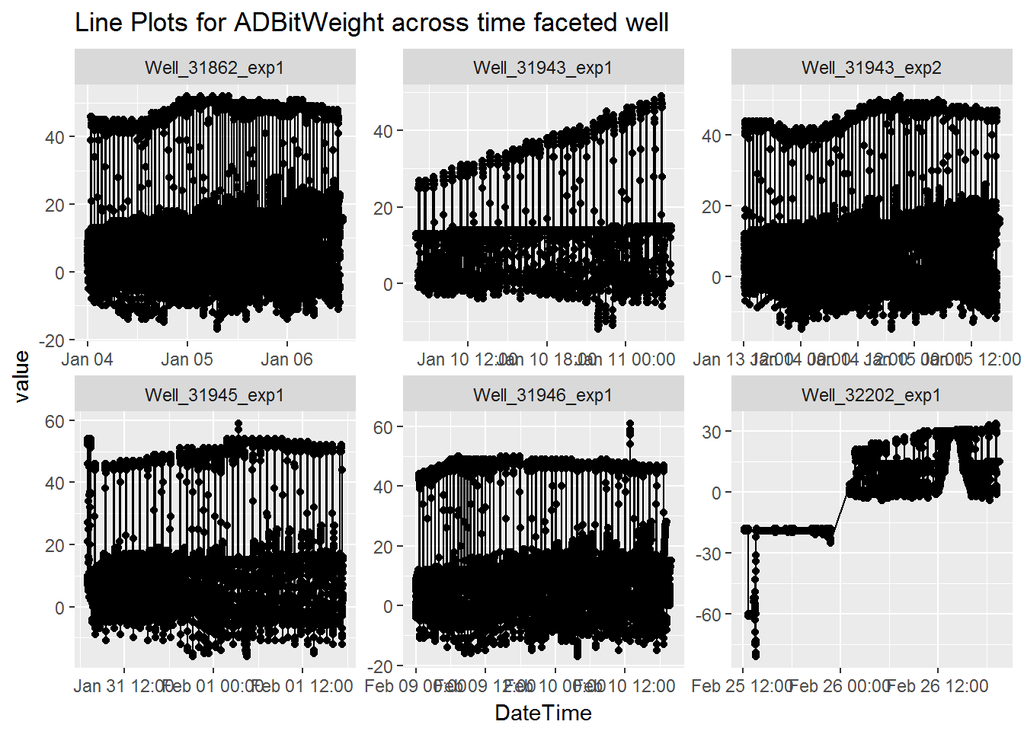

```r
  title <- paste("Line Plots for ADBitWeight across time faceted well")
  p = ggplot(data = dfm_ADBitWeight, aes_string(x = "DateTime", y = "value")) + geom_line()
  p = p + geom_point()
  p = p + facet_wrap(~ Depth , scales="free")
  p = p + ggtitle(title)
  p
```

Then, there was class labelling. Last two hours were skipped and the event was considered to last for three hours

```r
## Class labelling
## Need to use time to do the class labelling
## Class labelling
df_1_31862_exp1 = DrillingClassLabel(skipHours = 2, eventHours = 3, dataSource = df_1_31862_exp1)
df_1_31943_exp1 = DrillingClassLabel(skipHours = 2, eventHours = 3, dataSource = df_1_31943_exp1)
df_1_31943_exp2 = DrillingClassLabel(skipHours = 2, eventHours = 3, dataSource = df_1_31943_exp2)
df_1_31945_exp1 = DrillingClassLabel(skipHours = 2, eventHours = 3, dataSource = df_1_31945_exp1)
df_1_31946_exp1 = DrillingClassLabel(skipHours = 2, eventHours = 3, dataSource = df_1_31946_exp1)
df_1_32202_exp1 = DrillingClassLabel(skipHours = 2, eventHours = 3, dataSource = df_1_32202_exp1)
```

Explore if there is any strong correlation between different variables

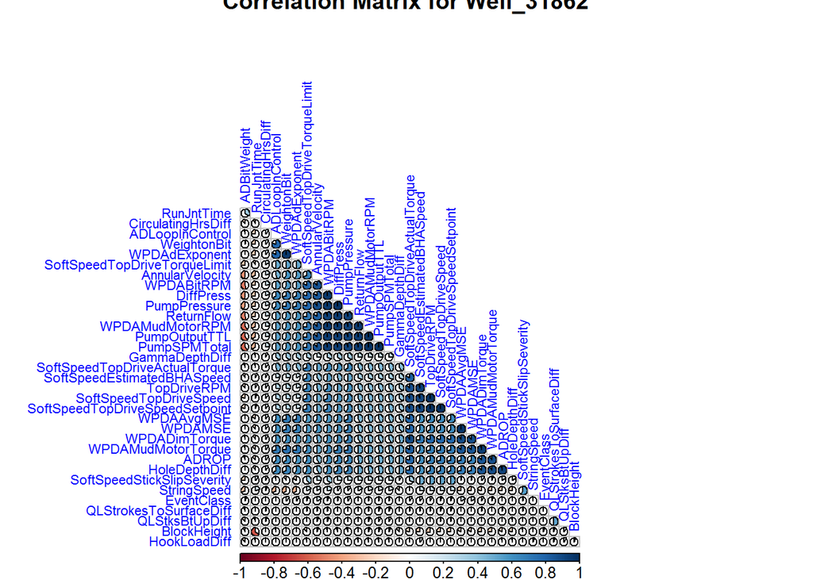

```r
cor_31862_exp1 = cor(df_1_31862_exp1[,c(2:ncol(df_1_31862_exp1))])
corrplot(cor_31862_exp1, tl.cex = 0.7, method = "pie", type = "lower", bg = "white", diag = FALSE, tl.col = "blue", cl.ratio = 0.1,  order ="hclust" , title = "Correlation Matrix for Well_31862")
```

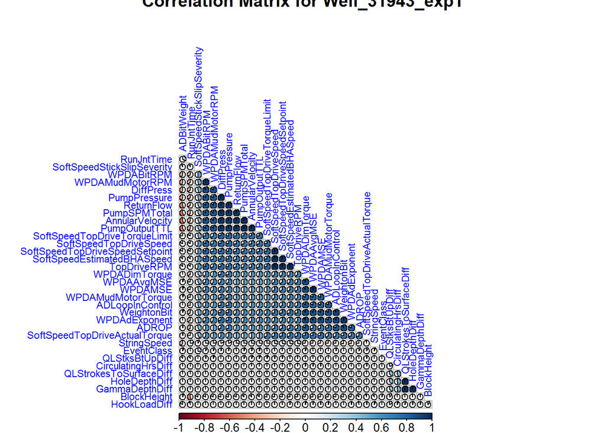

```r
cor_31943_exp1 = cor(df_1_31943_exp1[,c(2:ncol(df_1_31943_exp1))])
corrplot(cor_31943_exp1, tl.cex = 0.7, method = "pie", type = "lower", bg = "white", diag = FALSE, tl.col = "blue", cl.ratio = 0.1,  order ="hclust", title = "Correlation Matrix for Well_31943_exp1" )
```

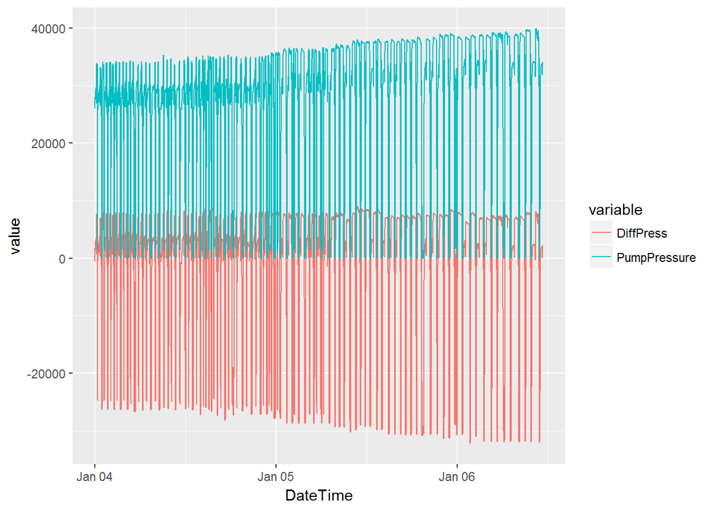

```r
df_1_31862_exp1_melt = melt(df_1_31862_exp1, id.vars = "DateTime")
df_1_31862_LinearCorr = df_1_31862_exp1_melt[df_1_31862_exp1_melt$variable %in% c("PumpPressure", "DiffPress"),]
ggplot(data = df_1_31862_LinearCorr, aes(x = DateTime, y  = value)) + geom_line(aes(colour = variable))
```

Silently remove data time

Load importance data frame

```r
load("TransformationSummaryFiles_V2.RData")
dfImp = df_Importance
aggImp = aggregate(dfImp[,c("VariableImportance")], by = list(dfImp$VariableName), "sum")
aggImp[order(aggImp$x, decreasing = TRUE),]
```

```
##                           Group.1         x
## 12                   PumpPressure 246.59145
## 17                     RunJntTime 217.94265
## 7                       DiffPress 189.37785
## 32                WPDAMudMotorRPM 147.94068
## 20  SoftSpeedTopDriveActualTorque 138.98890
## 5                     BlockHeight 131.92191
## 1                     ADBitWeight 114.86359
## 11                  PumpOutputTTL 113.95985
## 4                 AnnularVelocity 106.88309
## 26                    WeightonBit  90.06375
## 19     SoftSpeedStickSlipSeverity  88.76279
## 28                     WPDABitRPM  85.31446
## 33             WPDAMudMotorTorque  80.97177
## 31                        WPDAMSE  79.13966
```

[output cut: 19 more lines]

List of Variables from Kurt

```r
## All removed variables with reason
df_Removed = rbind(dfRemAccumtCols, dfRemConstCols, dfRemExploitCols, dfRemMissCols)
df_Removed
```

```
##                             FeatureName
## 1                        AccumRotations
## 2                              BitHours
## 3                           BitPosition
## 4                                BitTVD
## 5                        CirculatingHrs
## 6                            CutandSlip
## 7                            GammaDepth
## 8                             KellyDown
## 9                            PipeLength
## 10                     PipeLengthChange
## 11                         QLStartDepth
## 12                SoftSpeedStringLength
## 13                         StringLength
## 14                            StrksFill
```

[output cut: 275 more lines]

```r
KurtVariables = c("HoleDepth","ADROP","BitHours","BitPosition","BitTVD","GammaRay","HookLoad","PumpOutputTTL","ROPAverage","ROPFast","SoftSpeedEstimatedBHASpeed","SoftSpeedStickSlipSeverity","SvyInclination","TopDriveRPM",
                  "TopDriveTorque","WeightOnBit","SoftSpeedActive","DiffPressure","PumpPressure","BitSize",
                  "TVD")
KurtVariables
```

```
##  [1] "HoleDepth"                  "ADROP"
##  [3] "BitHours"                   "BitPosition"
##  [5] "BitTVD"                     "GammaRay"
##  [7] "HookLoad"                   "PumpOutputTTL"
##  [9] "ROPAverage"                 "ROPFast"
## [11] "SoftSpeedEstimatedBHASpeed" "SoftSpeedStickSlipSeverity"
## [13] "SvyInclination"             "TopDriveRPM"
## [15] "TopDriveTorque"             "WeightOnBit"
## [17] "SoftSpeedActive"            "DiffPressure"
## [19] "PumpPressure"               "BitSize"
## [21] "TVD"
```

```r
myVariables = names(df_1_31862)
myVariables
```

```
##  [1] "DateTime"
##  [2] "HoleDepth"
##  [3] "AccumTripOut"
##  [4] "ADBitWeight"
##  [5] "ADLoopInControl"
##  [6] "ADROP"
##  [7] "AnnularVelocity"
##  [8] "BHALength"
##  [9] "BitSize"
## [10] "BitStatus"
## [11] "BlockHeight"
## [12] "CoManGL"
## [13] "DegasserTankS10DAQ"
## [14] "DiffPress"
## [15] "GainLoss"
```

[output cut: 83 more lines]

```r
lostVars = KurtVariables[!(KurtVariables %in% myVariables)]
lostVars
```

```
##  [1] "BitHours"       "BitPosition"    "BitTVD"         "GammaRay"
##  [5] "HookLoad"       "ROPAverage"     "ROPFast"        "SvyInclination"
##  [9] "TopDriveTorque" "WeightOnBit"    "DiffPressure"   "TVD"
```

```r
# where are the lost variables
df_Removed[df_Removed$FeatureName %in% lostVars, ]
```

```
##        FeatureName                                   Reason  WellName
## 2         BitHours Accum Columns Replaced with Diff Columns All Wells
## 3      BitPosition Accum Columns Replaced with Diff Columns All Wells
## 4           BitTVD Accum Columns Replaced with Diff Columns All Wells
## 15             TVD Accum Columns Replaced with Diff Columns All Wells
## 18        HookLoad Accum Columns Replaced with Diff Columns All Wells
## 127       GammaRay   Missing Columns - More than 5% of rows All Wells
## 129     ROPAverage   Missing Columns - More than 5% of rows All Wells
## 132        ROPFast   Missing Columns - More than 5% of rows All Wells
## 134 SvyInclination   Missing Columns - More than 5% of rows All Wells
##     Version
## 2      Main
## 3      Main
## 4      Main
## 15     Main
## 18     Main
## 127    Main
## 129    Main
## 132    Main
## 134    Main
```

```r
## extra variables
extraVars = myVariables[!(myVariables %in% KurtVariables)]
extraVars
```

```
##  [1] "DateTime"
##  [2] "AccumTripOut"
##  [3] "ADBitWeight"
##  [4] "ADLoopInControl"
##  [5] "AnnularVelocity"
##  [6] "BHALength"
##  [7] "BitStatus"
##  [8] "BlockHeight"
##  [9] "CoManGL"
## [10] "DegasserTankS10DAQ"
## [11] "DiffPress"
## [12] "GainLoss"
## [13] "GainLossSpare"
## [14] "Last24HrWear"
## [15] "LstElemLen"
```

[output cut: 74 more lines]

Compile results to compare the accuracy of different algorithms

Results for well_31862

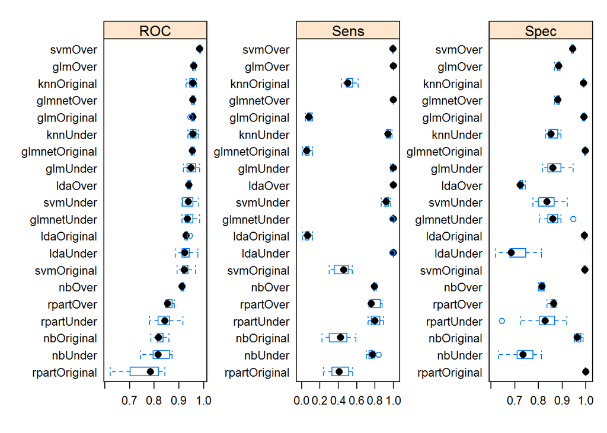

```r
load("df_1_31862_exp1_models.rda")
well_31862_results <- resamples(list(glmOriginal = listOfModels[["glmOriginal"]],
                            glmUnder = listOfModels[["glmUnder"]],
                            glmOver = listOfModels[["glmOver"]],

                            ldaOriginal=listOfModels[["ldaOriginal"]],
                            ldaUnder = listOfModels[["ldaUnder"]],
                            ldaOver = listOfModels[["ldaOver"]],

                           glmnetOriginal=listOfModels[["glmnetOriginal"]],
                            glmnetUnder = listOfModels[["glmnetUnder"]],
                            glmnetOver = listOfModels[["glmnetOver"]],

                            knnOriginal=listOfModels[["knnOriginal"]],
                            knnUnder = listOfModels[["knnUnder"]],

                            rpartOriginal=listOfModels[["rpartOriginal"]],
                            rpartUnder= listOfModels[["rpartUnder"]],
                            rpartOver = listOfModels[["rpartOver"]],

                            svmOriginal=listOfModels[["svmOriginal"]],
                            svmUnder = listOfModels[["svmUnder"]],
                            svmOver = listOfModels[["svmOver"]],
                            nbOriginal =  listOfModels[["nbOriginal"]],
                           nbUnder  = listOfModels[["nbUnder"]],
                           nbOver = listOfModels[["nbOver"]]

                            ))
scales = list(x = list(relation = "free"), y = list(relation = "free"))
bwplot(well_31862_results, scales = scales)
```

```r
## remove all models
rm(listOfModels)
```

Results for well_31943

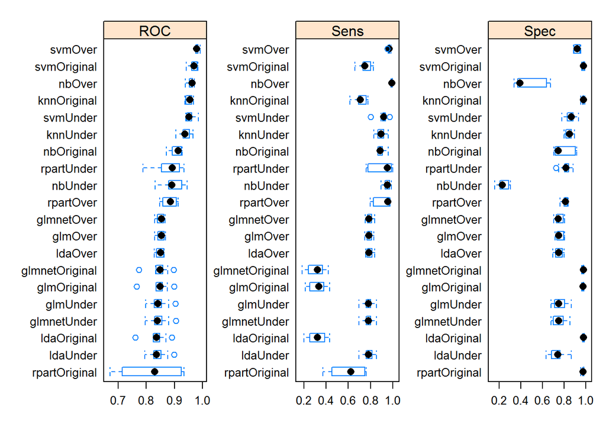

```r
load("df_1_31943_exp1_models.rda")
well_31943_results <- resamples(list(glmOriginal = listOfModels[["glmOriginal"]],
                            glmUnder = listOfModels[["glmUnder"]],
                            glmOver = listOfModels[["glmOver"]],

                            ldaOriginal=listOfModels[["ldaOriginal"]],
                            ldaUnder = listOfModels[["ldaUnder"]],
                            ldaOver = listOfModels[["ldaOver"]],

                           glmnetOriginal=listOfModels[["glmnetOriginal"]],
                            glmnetUnder = listOfModels[["glmnetUnder"]],
                            glmnetOver = listOfModels[["glmnetOver"]],

                            knnOriginal=listOfModels[["knnOriginal"]],
                            knnUnder = listOfModels[["knnUnder"]],

                            rpartOriginal=listOfModels[["rpartOriginal"]],
                            rpartUnder= listOfModels[["rpartUnder"]],
                            rpartOver = listOfModels[["rpartOver"]],

                            svmOriginal=listOfModels[["svmOriginal"]],
                            svmUnder = listOfModels[["svmUnder"]],
                            svmOver = listOfModels[["svmOver"]],
                            nbOriginal =  listOfModels[["nbOriginal"]],
                           nbUnder  = listOfModels[["nbUnder"]],
                           nbOver = listOfModels[["nbOver"]]

                            ))
scales = list(x = list(relation = "free"), y = list(relation = "free"))
bwplot(well_31943_results, scales = scales)
```

```r
## remove all models
rm(listOfModels)
```

Results for well_31943_exp2

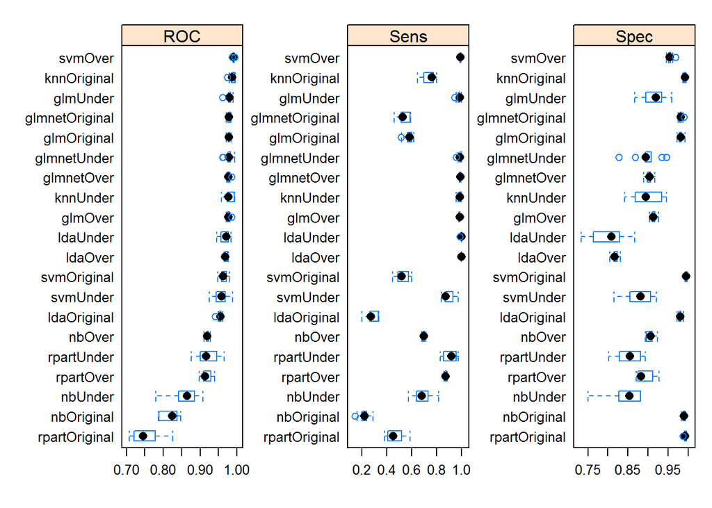

```r
load("df_1_31943_exp2_models.rda")
well_31943_exp2_results <- resamples(list(glmOriginal = listOfModels[["glmOriginal"]],
                            glmUnder = listOfModels[["glmUnder"]],
                            glmOver = listOfModels[["glmOver"]],

                            ldaOriginal=listOfModels[["ldaOriginal"]],
                            ldaUnder = listOfModels[["ldaUnder"]],
                            ldaOver = listOfModels[["ldaOver"]],

                           glmnetOriginal=listOfModels[["glmnetOriginal"]],
                            glmnetUnder = listOfModels[["glmnetUnder"]],
                            glmnetOver = listOfModels[["glmnetOver"]],

                            knnOriginal=listOfModels[["knnOriginal"]],
                            knnUnder = listOfModels[["knnUnder"]],

                            rpartOriginal=listOfModels[["rpartOriginal"]],
                            rpartUnder= listOfModels[["rpartUnder"]],
                            rpartOver = listOfModels[["rpartOver"]],

                            svmOriginal=listOfModels[["svmOriginal"]],
                            svmUnder = listOfModels[["svmUnder"]],
                            svmOver = listOfModels[["svmOver"]],
                            nbOriginal =  listOfModels[["nbOriginal"]],
                           nbUnder  = listOfModels[["nbUnder"]],
                           nbOver = listOfModels[["nbOver"]]

                            ))
scales = list(x = list(relation = "free"), y = list(relation = "free"))
bwplot(well_31943_exp2_results, scales = scales)
```

```r
## remove all models
rm(listOfModels)
```

Results for well_31945_exp1

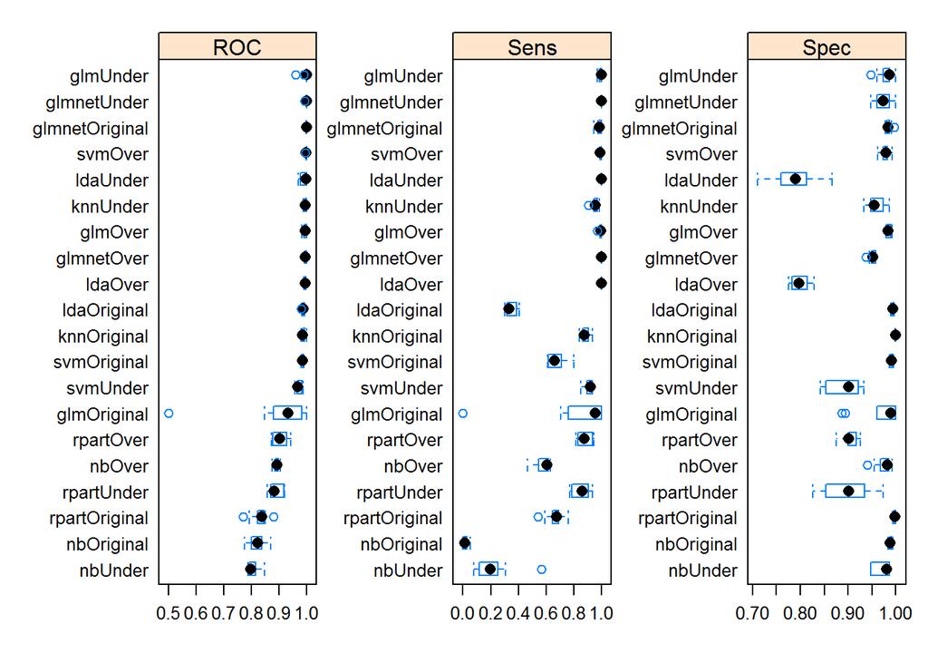

```r
load("df_1_31945_exp1_models.rda")
well_31945_results <- resamples(list(glmOriginal = listOfModels[["glmOriginal"]],
                            glmUnder = listOfModels[["glmUnder"]],
                            glmOver = listOfModels[["glmOver"]],

                            ldaOriginal=listOfModels[["ldaOriginal"]],
                            ldaUnder = listOfModels[["ldaUnder"]],
                            ldaOver = listOfModels[["ldaOver"]],

                           glmnetOriginal=listOfModels[["glmnetOriginal"]],
                            glmnetUnder = listOfModels[["glmnetUnder"]],
                            glmnetOver = listOfModels[["glmnetOver"]],

                            knnOriginal=listOfModels[["knnOriginal"]],
                            knnUnder = listOfModels[["knnUnder"]],

                            rpartOriginal=listOfModels[["rpartOriginal"]],
                            rpartUnder= listOfModels[["rpartUnder"]],
                            rpartOver = listOfModels[["rpartOver"]],

                            svmOriginal=listOfModels[["svmOriginal"]],
                            svmUnder = listOfModels[["svmUnder"]],
                            svmOver = listOfModels[["svmOver"]],
                            nbOriginal =  listOfModels[["nbOriginal"]],
                           nbUnder  = listOfModels[["nbUnder"]],
                           nbOver = listOfModels[["nbOver"]]

                            ))
scales = list(x = list(relation = "free"), y = list(relation = "free"))
bwplot(well_31945_results, scales = scales)
```

```r
## remove all models
rm(listOfModels)
```

Results for well_31946_exp1

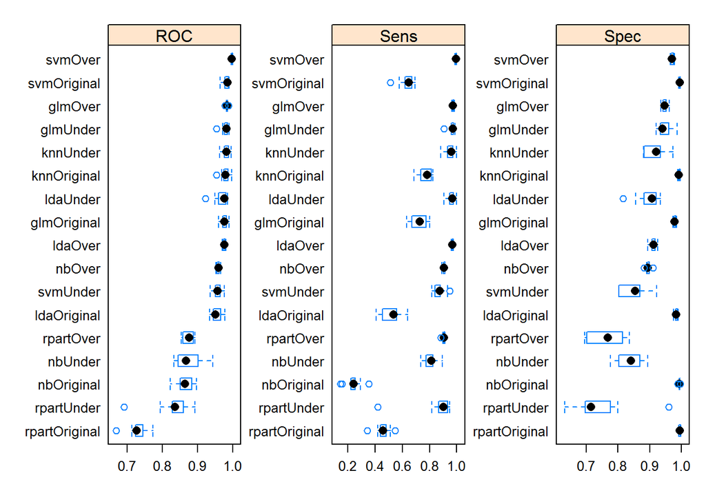

```r
load("df_1_31946_exp1_models.rda")
well_31946_results <- resamples(list(glmOriginal = listOfModels[["glmOriginal"]],
                            glmUnder = listOfModels[["glmUnder"]],
                            glmOver = listOfModels[["glmOver"]],

                            ldaOriginal=listOfModels[["ldaOriginal"]],
                            ldaUnder = listOfModels[["ldaUnder"]],
                            ldaOver = listOfModels[["ldaOver"]],

                            knnOriginal=listOfModels[["knnOriginal"]],
                            knnUnder = listOfModels[["knnUnder"]],

                            rpartOriginal=listOfModels[["rpartOriginal"]],
                            rpartUnder= listOfModels[["rpartUnder"]],
                            rpartOver = listOfModels[["rpartOver"]],

                            svmOriginal=listOfModels[["svmOriginal"]],
                            svmUnder = listOfModels[["svmUnder"]],
                            svmOver = listOfModels[["svmOver"]],
                            nbOriginal =  listOfModels[["nbOriginal"]],
                           nbUnder  = listOfModels[["nbUnder"]],
                           nbOver = listOfModels[["nbOver"]]

                            ))
scales = list(x = list(relation = "free"), y = list(relation = "free"))
bwplot(well_31946_results, scales = scales)
```

```r
## remove all models
rm(listOfModels)
```

Results for well_32202_exp1

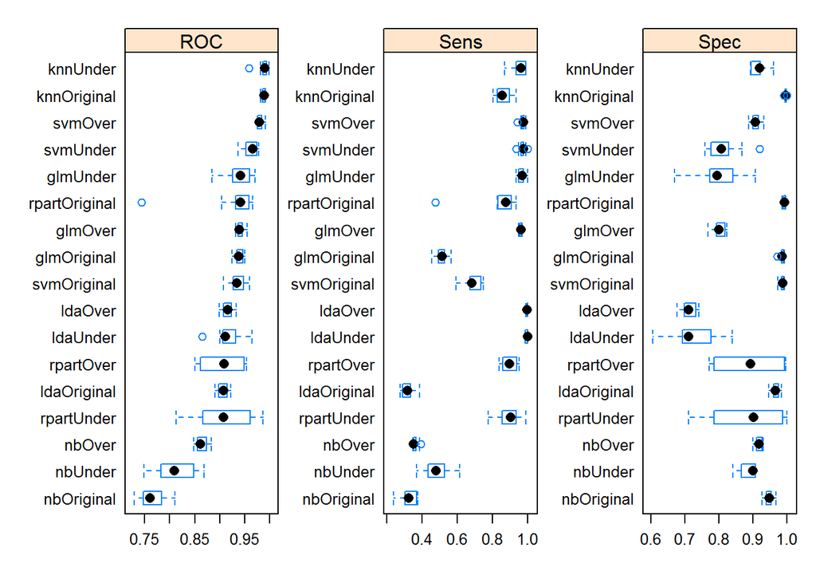

```r
load("df_1_32202_exp1_models.rda")
well_32202_results <- resamples(list(glmOriginal = listOfModels[["glmOriginal"]],
                            glmUnder = listOfModels[["glmUnder"]],
                            glmOver = listOfModels[["glmOver"]],

                            ldaOriginal=listOfModels[["ldaOriginal"]],
                            ldaUnder = listOfModels[["ldaUnder"]],
                            ldaOver = listOfModels[["ldaOver"]],

                            knnOriginal=listOfModels[["knnOriginal"]],
                            knnUnder = listOfModels[["knnUnder"]],

                            rpartOriginal=listOfModels[["rpartOriginal"]],
                            rpartUnder= listOfModels[["rpartUnder"]],
                            rpartOver = listOfModels[["rpartOver"]],

                            svmOriginal=listOfModels[["svmOriginal"]],
                            svmUnder = listOfModels[["svmUnder"]],
                            svmOver = listOfModels[["svmOver"]],
                            nbOriginal =  listOfModels[["nbOriginal"]],
                           nbUnder  = listOfModels[["nbUnder"]],
                           nbOver = listOfModels[["nbOver"]]

                            ))
scales = list(x = list(relation = "free"), y = list(relation = "free"))
bwplot(well_32202_results, scales = scales)
```

```r
## remove all models
rm(listOfModels)
```